# Assignment: Statistical Inference Course Project

# Part 1: Simulation Exercise

In this project you will investigate the exponential distribution in R and compare it with the Central Limit Theorem. The exponential distribution can be simulated in R with rexp(n, lambda) where lambda is the rate parameter. The mean of exponential distribution is 1/lambda and the standard deviation is also 1/lambda. Set lambda = 0.2 for all of the simulations. You will investigate the distribution of averages of 40 exponentials. Note that you will need to do a thousand simulations.

Illustrate via simulation and associated explanatory text the properties of the distribution of the mean of 40 exponentials. You should

- Show the sample mean and compare it to the theoretical mean of the distribution.
- Show how variable the sample is (via variance) and compare it to the theoretical variance of the distribution.
- Show that the distribution is approximately normal. Focus on the difference between the distribution of a large collection of random exponentials and the distribution of a large collection of averages of 40 exponentials.

# Part 2: Basic Inferential Data Analysis Instructions

Now in the second portion of the project, we’re going to analyze the ToothGrowth data in the R datasets package.

- Load the ToothGrowth data and perform some basic exploratory data analyses
- Provide a basic summary of the data.
- Use confidence intervals and/or hypothesis tests to compare tooth growth by supp and dose. (Only use the techniques from class, even if there’s other approaches worth considering)
- State your conclusions and the assumptions needed for your conclusions.

# Part 1

## Simulation

### Sample exponential distribution

```r
set.seed(2021) # for reproducability
nosim <- 1000 # no of simulations
n <- 40 # no of exponentials
lambda <- 0.2 # rate parameter

simdata <- matrix(rexp(nosim * n, rate=lambda), nosim)
sim_mean <- rowMeans(simdata) # row means

# Calculate mean, sd and variance of sample exp dist
simdata_mean <- mean(sim_mean)
simdata_sd <- sd(sim_mean)
simdata_var <- var(sim_mean)
```

### Theoretical exponential distribution

```r
# calculate mean, df and variance of theoretical exp dist
t_mean = 1/lambda
t_sd = (1/lambda) * (1/sqrt(n))
t_var = t_sd^2
```

## Histogram of sample exponential distribution vs Averages of simulated exponentials.

```r
par(mfrow = c(1, 2))
hist(simdata,
     col = "steelblue",
     main = "Simulated exponential distribution",
     xlab = "40 random exponentials")
hist(sim_mean,
     col = "red3",
     main = "Averages of Simulated Exponentials",
     xlab = "Average of 40 exponentials")
```

[figure not shown]

```r
abline(v = t_mean, col = "green", lwd = 2) # theoretical mean
```

## Comparison between sample and theoretical statistics

```r
Sample_stats <- c(simdata_mean, simdata_sd, simdata_var)
Theoretical_stats <- c(t_mean, t_sd, t_var)
diff <- c(abs(t_mean - simdata_mean), abs(t_sd - simdata_sd), t_var - simdata_var)
names <- c("Mean", "Std", "Variance")
data.frame(Sample_stats, Theoretical_stats, diff, row.names =  c("Mean", "Std", "Variance"))
```

|  | Sample_stats | Theoretical_stats | diff |
| --- | --- | --- | --- |
| Mean | 5.0086386 | 5.0000000 | 0.008638602 |
| Std | 0.7882570 | 0.7905694 | 0.002312423 |
| Variance | 0.6213491 | 0.6250000 | 0.003650915 |

## Distribution

### Histogram and Density plot

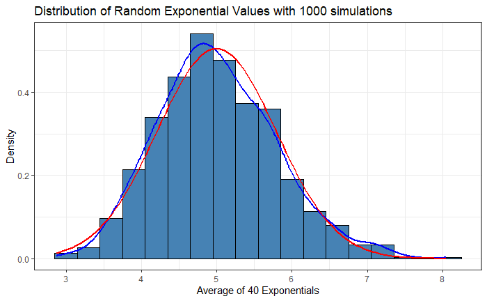

```r
library(ggplot2)
simdata_mean <- data.frame(sim_mean)
ggplot(simdata_mean, aes(sim_mean)) + geom_histogram(binwidth = .3,
                                                    fill = "steelblue",
                                                    color = "black",
                                                    aes(y = ..density..)) +
    geom_density(color = "blue", lwd = 1) + labs(title = "Distribution of Random Exponential Values with 1000 simulations", x = "Average of 40 Exponentials", y = "Density") + stat_function( fun = dnorm,
                                                                                args = list(mean = t_mean, sd = t_sd),
                                                                                color = "red",
                                                                                lwd = 1 ) + theme_bw()
```

### Q-Q plot

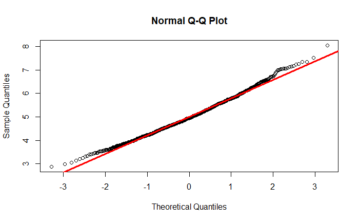

```r
qqnorm(sim_mean, col="black") # sample distribution
qqline(sim_mean, col="red", lwd=3) #theoretical
```

# Part 2

## Load data

```r
data("ToothGrowth")
dt <- ToothGrowth
```

## Basic exploratory Data Analyses

```r
str(dt)
```

```
'data.frame':   60 obs. of  3 variables:
 $ len : num  4.2 11.5 7.3 5.8 6.4 10 11.2 11.2 5.2 7 ...
 $ supp: Factor w/ 2 levels "OJ","VC": 2 2 2 2 2 2 2 2 2 2 ...
 $ dose: num  0.5 0.5 0.5 0.5 0.5 0.5 0.5 0.5 0.5 0.5 ...
```

```r
unique(dt$dose)
```

```
[1] 0.5 1.0 2.0
```

```r
dt$dose <- factor(dt$dose)
str(dt)
```

```
'data.frame':   60 obs. of  3 variables:
 $ len : num  4.2 11.5 7.3 5.8 6.4 10 11.2 11.2 5.2 7 ...
 $ supp: Factor w/ 2 levels "OJ","VC": 2 2 2 2 2 2 2 2 2 2 ...
 $ dose: Factor w/ 3 levels "0.5","1","2": 1 1 1 1 1 1 1 1 1 1 ...
```

```r
summary(dt)
```

```
      len        supp     dose
 Min.   : 4.20   OJ:30   0.5:20
 1st Qu.:13.07   VC:30   1  :20
 Median :19.25           2  :20
 Mean   :18.81
 3rd Qu.:25.27
 Max.   :33.90
```

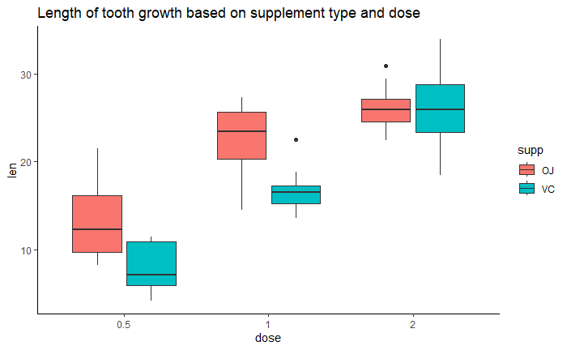

```r
library(ggplot2)
ggplot(dt, aes(x = dose, y = len, fill = supp)) + geom_boxplot() + ggtitle("Length of tooth growth based on supplement type and dose") + theme_classic()
```

```r
library(dplyr)
library(tidyr)

dt %>%
group_by(supp, dose) %>%
summarize(mean = mean(len), .groups='drop') %>%
spread(supp, mean) %>%
mutate(diff = abs(VC - OJ))
```

| dose | OJ | VC | diff |
| --- | --- | --- | --- |
| 0.5 | 13.23 | 7.98 | 5.25 |
| 1 | 22.70 | 16.77 | 5.93 |
| 2 | 26.06 | 26.14 | 0.08 |

## t.test Hypothesis Testing

```r
dose_half <- filter(dt, dose == 0.5)
dose_one <- filter(dt, dose == 1)
dose_two <- filter(dt, dose == 2)
```

### t-test for 0.5 mg/day dose

```r
t.test(len ~ supp, dose_half)
```

```
    Welch Two Sample t-test

data:  len by supp
t = 3.1697, df = 14.969, p-value = 0.006359
alternative hypothesis: true difference in means between group OJ and group VC is not equal to 0
95 percent confidence interval:
 1.719057 8.780943
sample estimates:
mean in group OJ mean in group VC
           13.23             7.98
```

### t-test for 1 mg/day dose

```r
t.test(len ~ supp, dose_one)
```

```
    Welch Two Sample t-test

data:  len by supp
t = 4.0328, df = 15.358, p-value = 0.001038
alternative hypothesis: true difference in means between group OJ and group VC is not equal to 0
95 percent confidence interval:
 2.802148 9.057852
sample estimates:
mean in group OJ mean in group VC
           22.70            16.77
```

### t-test for 2 mg/day dose

```r
t.test(len ~ supp, dose_two)
```

```
    Welch Two Sample t-test

data:  len by supp
t = -0.046136, df = 14.04, p-value = 0.9639
alternative hypothesis: true difference in means between group OJ and group VC is not equal to 0
95 percent confidence interval:
 -3.79807  3.63807
sample estimates:
mean in group OJ mean in group VC
           26.06            26.14
```

```r
dose <- c(0.5, 1.0, 2.0)
p_value <- c(0.0064, 0.0010, 0.9639)
conf.int <- c("1.72, 8.78", "2.80, 9.06", "-3.80, 3.64")
decision <- c("Reject null", "Reject null", "Do not reject null")
data.frame(dose, conf.int, p_value, decision)
```

| dose | conf.int | p_value | decision |
| --- | --- | --- | --- |
| 0.5 | 1.72, 8.78 | 0.0064 | Reject null |
| 1.0 | 2.80, 9.06 | 0.0010 | Reject null |
| 2.0 | -3.80, 3.64 | 0.9639 | Do not reject null |